# Simple document

Flora Pang

2024-09-10

Important because if just load tidyverse on console, when you knit the new environment is completely self-contained and won’t remember that you had loaded that onto the console. Need to make sure to load the tidyverse

Remember to see it in the html, need to knit not just run the code line

```r
library(tidyverse)
```

I’m an R Markdown document!

# Section 1

Here’s a **code chunk** that samples from a *normal distribution*:

```r
samp = rnorm(500)
length(samp)
```

```
## [1] 500
```

# Section 2

I can take the mean of the sample, too! The mean is -0.1018776.

# Learning Assessmemt

This code is for the learning assesment: click on option, command, i to get a flow chunk of R When do not know how to make something look at previous class the code that was used / Google

Code have to be in order

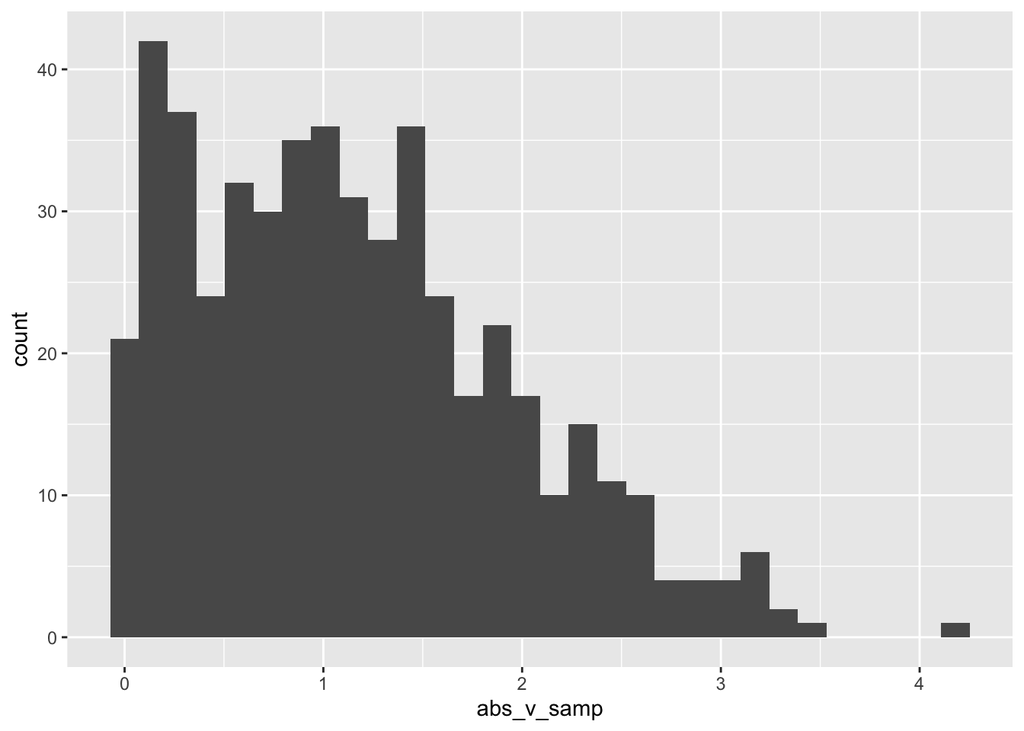

```r
library(tidyverse)

la_df =
  tibble(
    norm_samp = rnorm(n = 500, mean = 1),
    samp_geq1 = norm_samp > 0,
    abs_v_samp = abs(norm_samp)
  )

ggplot(la_df, aes(x = abs_v_samp)) +
  geom_histogram()
```

If i want to write a line of code here in R, to comment for myself but I do not want to have it show in the knit Can have a code and just not evaluate it

## Text formatting

*italic* or *italic* **bold** or **bold** `code` superscript<sup>2</sup> and subscript<sub>2</sub>

# 1st Level Header

## 2nd Level Header

### 3rd Level Header

## Lists

- Bulleted list item 1
- Item 2
  - Item 2a
  - Item 2b
1. Numbered list item 1
2. Item 2. The numbers are incremented automatically in the output.

## Tables

| First Header | Second Header |
| --- | --- |
| Content Cell | Content Cell |
| Content Cell | Content Cell |